# Building and visualizing pre-processing pipelines for cytometry data with CytoPipeline

Philippe Hauchamps [^1]

Last modified: 1 September, 2023.

# Overview

## Description

This workshop provides a life example on how to build, run and visualize cytometry data pre-processing pipelines, using the `CytoPipeline` suite of packages.

## Pre-requisites

- Basic familiarity with flow cytometry (FC) data and data structures (e.g. flowCore::flowFrame)
- Interest in building automated data pre-processing pipelines for cytometry data
- Some knowledge about typical cytometry data pre-processing steps: compensation, scale transformation, quality control of signal stability in time, removal of un-desirable events, like doublets, debris, dead cells,etc. A good overview article is (Liechti et al. 2021).

## Participation

The present `.Rmd` file is designed to support, either an instructor-led live demo, or a lab format where participants run the example code on their own.  
Therefore it is up to you to decide how to spend your time during the workshop, either by listening to the instructor, or by running the code chunks one by one at your own pace, or a combination of both.

## *R* / *Bioconductor* packages used

- CytoPipeline (available in *Bioconductor°* since 3.17)
- CytoPipelineGUI (submitted to *Bioconductor*, target version 3.18)
- CytoPipelineUtils (from public github repository)

## Time outline

| Activity | Time |
| --- | --- |
| Introduction | 10m |
| Creating a CytoPipeline object | 10m |
| Executing and visualizing the pipeline run | 15m |
| Visualization of scale transformations | 5m |
| Technical options to fine-tune pipeline execution | 5m |

## Workshop goals and objectives

- understand the basic concepts and infrastructure used by the `CytoPipeline` suite of package.
- build and run a cytometry data pre-processing pipeline using `CytoPipeline`, on a simple example FC dataset.
- understand the added value of the visualization tools (`CYtoPipelineGUI`) for assessing the quality of the pipeline.

# Workshop

## Introduction

### Context

Automated analysis of cytometry data can be schematically split into different big parts, as is shown in Figure 1.

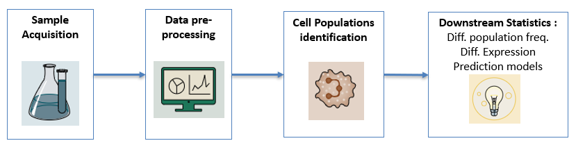

Fig. 1: high level workflow for cytometry data analysis - adapted from (Liechti et al, 2021).

The `CytoPipeline` packages suite is aimed at facilitating the design and assessment of automated pre-processing pipelines for cytometry data analysis. This means that we are targeting the ‘Data pre-processing’ box in Figure 1.

For flow cytometry data, this pre-processing part typically contains the following steps: - *signal compensation*, i.e. a linear transformation of the intensity matrix, in order to cope with *spillover* of channel light signal to the other channels  
- *scale transformation*, i.e. non linear transformation of fluorescent signal, in order to better to obtain a better separation between cell populations  
- *QC in time*, i.e. control of signal stability in time  
- filtering of undesirable events like *margins* (outliers), debris, doublets and dead cells.

### The example dataset

The example dataset that will be used throughout this vignette is derived from a reference public dataset accompanying the OMIP-021 (Optimized Multicolor Immunofluorescence Panel 021) article (Gherardin et al, 2014).

A sub-sample of this public dataset, with 2 *fcs* files containing measurements of 16 markers for 5,000 events each, is built-in in the `CytoPipeline` package, as the *OMIP021* dataset.

See the `MakeOMIP021Samples.R` script for more details on how the `OMIP021` dataset was created. This script is to be found in the `script` subdirectory in the `CytoPipeline` package installation path.

### Target pipelines

In this workshop, we will pre-process the two samples of our dataset, using two different pipeline set-ups, aiming at comparing two different QC in time methods : - *flowAI* (Monaco et al, 2016) - *PeacoQC* (Emmaneel et al, 2021).

In both pipelines, the first part consists in estimating appropriate scale transformation functions for all channels present in the sample `flowFrame`. In order to do this, we propose the following *scale transformation processing queue* (Fig. 2):

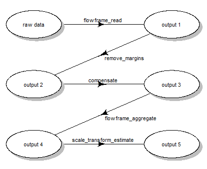

Fig.2 : Scale transform processing queue

When this first part is done, one can apply pre-processing for each file one by one. However, depending on the choice of QC in time method, the order of steps needs to be slightly different:

- when using *flowAI*, it is advised to eliminate the ‘bad events’ starting from raw data - see (Monaco et al, 2016).
- when using *PeacoQC*, it is advised to eliminate the ‘bad events’ from already compensated and scale transformed data - see (Emmaneel et al, 2021).

Therefore, we propose the following *pre-processing queues* represented in Fig. 3.

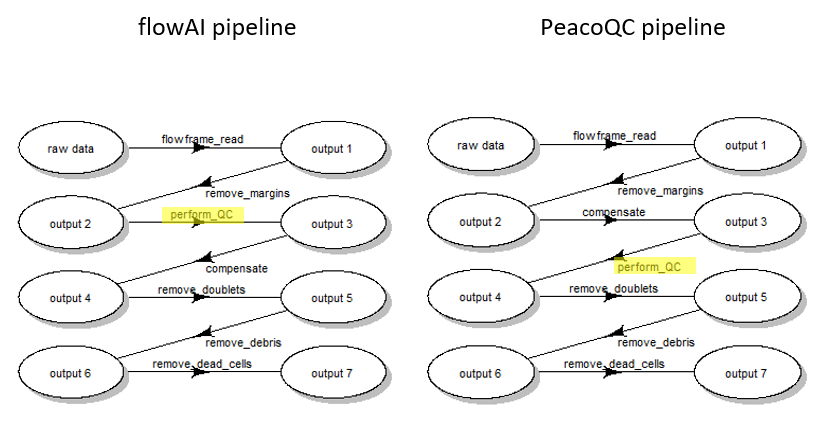

Fig. 3 : Pre-processing queue for two different pipeline settings

### Essential CytoPipeline concepts

The *CytoPipeline* framework is based on two main concepts, namely *CytoPipeline* and *CytoProcessingSteps*. A *CytoPipeline* object centralizes the pipeline definition, and specifies the run order of the different pipeline steps. On top of the steps definition, it also has an *experimentName* as a key for storing the results, and a vector of sample files on which to run the pipeline.

These *CytoPipeline* steps materialize as *CytoProcessingStep* objects, which store pipeline step names and the corresponding R functions that will be called at execution time. These functions are either provided within the *CytoPipeline* package itself, exported from third party packages, or coded by the user themself. Together with the function name to be called, a *CytoProcessingStep* object also contains the list of parameters that are used as arguments to the function.

## Creating a CytoPipeline object

There are essentially two ways to create a *CytoPipeline* object, either by defining the *CytoProcessingStep* one by one using R code, or by providing a json file as in input.

### Step by step creation in R code

Here we show an extract on how to build the pipeline step by step in R code, showing only the code to include the first two steps for building the scale transformation.

When done, we print the content of the *CytoPipeline* object.

```r
expName <- "CytoPipeline_Demo"

pipL0 <- CytoPipeline(experimentName = expName,
                      sampleFiles = mySamples)

### SCALE TRANSFORMATION STEPS ###

pipL0 <- addProcessingStep(pipL0,
                           whichQueue = "scale transform",
                           CytoProcessingStep(
                                name = "flowframe_read",
                                FUN = "readSampleFiles",
                                ARGS = list(
                                    whichSamples = "all",
                                    truncate_max_range = FALSE,
                                    min.limit = NULL
                                )))

pipL0 <- addProcessingStep(pipL0,
                           whichQueue = "scale transform",
                           CytoProcessingStep(
                               name = "remove_margins",
                               FUN = "removeMarginsPeacoQC",
                               ARGS = list()))

pipL0
Pipeline object for flow cytometry experiment: CytoPipeline_Demo
Sample files: 2 sample file(s)
No pheno data
Scale transformations evaluation queue : 2 processing step(s)
1 :Object of class "CytoProcessingStep"
 Name: flowframe_read
 Function: readSampleFiles
 Arguments:
  o whichSamples = all
  o truncate_max_range = FALSE
  o min.limit =
2 :Object of class "CytoProcessingStep"
 Name: remove_margins
 Function: removeMarginsPeacoQC
Flow frames pre-processing evaluation queue has no processing step
```

### Centralizing the pipeline definition in a json file

However, the easiest, and most concise way to define a *CytoPipeline* object is by using a json file. Here we will use the following input file, which specifies the *flowAI* pipeline as described above.

```r
jsonFile <- ("CytoPipeline_Demo_fAI.json")
cat(readLines(jsonFile), sep = '\n')
{
  "scaleTransformProcessingSteps": [
    {
      "name": ["flowframe_read"],
      "FUN": ["readSampleFiles"],
      "ARGS": {
        "whichSamples": ["all"],
        "truncate_max_range": [false],
        "min.limit": null
      }
    },
    {
      "name": ["remove_margins"],
      "FUN": ["removeMarginsPeacoQC"],
      "ARGS": {
        "channelSpecifications": {
          "AllFluoChannels": [-300, 262144]
        }
      }
    },
    {
      "name": ["compensate"],
      "FUN": ["compensateFromMatrix"],
      "ARGS": {
        "matrixSource": ["fcs"]
      }
    },
    {
      "name": ["flowframe_aggregate"],
      "FUN": ["aggregateAndSample"],
      "ARGS": {
        "nTotalEvents": [10000],
        "seed": [0]
      }
    },
    {
      "name": ["scale_transform_estimate"],
      "FUN": ["estimateScaleTransforms"],
      "ARGS": {
        "fluoMethod": ["estimateLogicle"],
        "scatterMethod": ["linearQuantile"],
        "scatterRefMarker": ["CD4"]
      }
    }
  ],
  "flowFramesPreProcessingSteps": [
    {
      "name": ["flowframe_read"],
      "FUN": ["readSampleFiles"],
      "ARGS": {
        "truncate_max_range": [false],
        "min.limit": null
      }
    },
    {
      "name": ["remove_margins"],
      "FUN": ["removeMarginsPeacoQC"],
      "ARGS": {
        "channelSpecifications": {
          "AllFluoChannels": [-300, 262144]
        }
      }
    },
    {
      "name": ["perform_QC"],
      "FUN": ["qualityControlFlowAI"],
      "ARGS": {
        "preTransform": [false],
        "remove_from": ["all"],
        "second_fractionFR": [0.1],
        "deviationFR": ["MAD"],
        "alphaFR": [0.01],
        "decompFR": [true],
        "outlier_binsFS": [false],
        "pen_valueFS": [200],
        "max_cptFS": [3],
        "sideFM": ["both"],
        "neg_valuesFM": [1]
      }
    },
    {
      "name": ["compensate"],
      "FUN": ["compensateFromMatrix"],
      "ARGS": {
        "matrixSource": ["fcs"]
      }
    },
    {
      "name": ["remove_doublets"],
      "FUN": ["removeDoubletsCytoPipeline"],
      "ARGS": {
        "areaChannels": ["FSC-A"],
        "heightChannels": ["FSC-H"],
        "nmads": [3]
      }
    },
    {
      "name": ["remove_debris"],
      "FUN": ["removeDebrisFlowClustTmix"],
      "ARGS": {
        "FSCChannel": ["FSC-A"],
        "SSCChannel": ["SSC-A"],
        "nClusters": [2],
        "level": [0.97],
        "B": [100]}
    },
    {
      "name": ["remove_dead_cells"],
      "FUN": ["removeDeadCellsDeGate"],
      "ARGS": {
        "preTransform": [true],
        "LDMarker": ["L/D Aqua - Viability"]
      }
    }
  ]
}
```

We now create our *CytoPipeline* object using this json file as input, and print the content of the object again.

```r
# 1.


# creation of CytoPipeline object,
# using json file as input
pipL <- CytoPipeline(jsonFile,
                     experimentName = expName,
                     sampleFiles = mySamples)

# display CytoPipeline object
pipL
Pipeline object for flow cytometry experiment: CytoPipeline_Demo
Sample files: 2 sample file(s)
No pheno data
Scale transformations evaluation queue : 5 processing step(s)
1 :Object of class "CytoProcessingStep"
 Name: flowframe_read
 Function: readSampleFiles
 Arguments:
  o whichSamples = all
  o truncate_max_range = FALSE
  o min.limit =
2 :Object of class "CytoProcessingStep"
 Name: remove_margins
 Function: removeMarginsPeacoQC
 Arguments:
  o channelSpecifications = c(-300, 262144)
3 :Object of class "CytoProcessingStep"
 Name: compensate
 Function: compensateFromMatrix
 Arguments:
  o matrixSource = fcs
4 :Object of class "CytoProcessingStep"
 Name: flowframe_aggregate
 Function: aggregateAndSample
 Arguments:
  o nTotalEvents = 10000
  o seed = 0
5 :Object of class "CytoProcessingStep"
 Name: scale_transform_estimate
 Function: estimateScaleTransforms
 Arguments:
  o fluoMethod = estimateLogicle
  o scatterMethod = linearQuantile
  o scatterRefMarker = CD4
Flow frames pre-processing evaluation queue : 7 processing step(s)
1 :Object of class "CytoProcessingStep"
 Name: flowframe_read
 Function: readSampleFiles
 Arguments:
  o truncate_max_range = FALSE
  o min.limit =
2 :Object of class "CytoProcessingStep"
 Name: remove_margins
 Function: removeMarginsPeacoQC
 Arguments:
  o channelSpecifications = c(-300, 262144)
3 :Object of class "CytoProcessingStep"
 Name: perform_QC
 Function: qualityControlFlowAI
 Arguments:
  o preTransform = FALSE
  o remove_from = all
  o second_fractionFR = 0.1
  o deviationFR = MAD
  o alphaFR = 0.01
  o decompFR = TRUE
  o outlier_binsFS = FALSE
  o pen_valueFS = 200
  o max_cptFS = 3
  o sideFM = both
  o neg_valuesFM = 1
4 :Object of class "CytoProcessingStep"
 Name: compensate
 Function: compensateFromMatrix
 Arguments:
  o matrixSource = fcs
5 :Object of class "CytoProcessingStep"
 Name: remove_doublets
 Function: removeDoubletsCytoPipeline
 Arguments:
  o areaChannels = FSC-A
  o heightChannels = FSC-H
  o nmads = 3
6 :Object of class "CytoProcessingStep"
 Name: remove_debris
 Function: removeDebrisFlowClustTmix
 Arguments:
  o FSCChannel = FSC-A
  o SSCChannel = SSC-A
  o nClusters = 2
  o level = 0.97
  o B = 100
7 :Object of class "CytoProcessingStep"
 Name: remove_dead_cells
 Function: removeDeadCellsDeGate
 Arguments:
  o preTransform = TRUE
  o LDMarker = L/D Aqua - Viability
```

As soon as the *CytoPipeline* object is created, it is possible to visualize the pipeline as a workflow plot, using the `CytoPipeline::plotCytoPipelineProcessingQueue()` function.

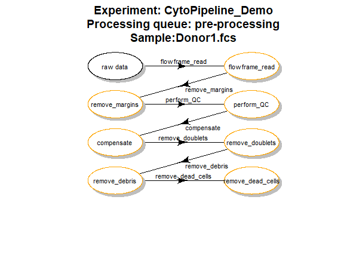

```r
plotCytoPipelineProcessingQueue(pipL,
                                whichQueue = "pre-processing",
                                path = resultsDir,
                                sampleFile = 1)
```

In this plot, each arrow represents a step (as defined by the user), and the results of each step is represented as a bubble. Here, all bubbles are colored in orange, meaning that there is no results yet available for these steps, since the pipeline has not been executed yet.

## Executing and visualizing the pipeline run

### Base pipeline

When the *CytoPipeline* object has been created with all needed steps, we can run it, by calling the `CytoPipeline::execute()` function.

```r
# 2.

# execute pipeline
try(execute(pipL, path = resultsDir))
```

```
#> #####################################################
#> ### running SCALE TRANSFORMATION processing steps ###
#> #####################################################
#> Proceeding with step 1 [flowframe_read] ...
#> Proceeding with step 2 [remove_margins] ...
#> Removing margins from file : Donor1.fcs
#> Removing margins from file : Donor2.fcs
#> Proceeding with step 3 [compensate] ...
#> Compensating file : Donor1.fcs
#> Compensating file : Donor2.fcs
#> Proceeding with step 4 [flowframe_aggregate] ...
#> Proceeding with step 5 [scale_transform_estimate] ...
#> estimating logicle transformations for fluorochrome channels...
#> Estimating linear transformation for scatter channels : reference marker = CD4...
#> applying specific linear transformation for FSC-A channel...
#> initial quantiles : q5 = 15825.9604 ; q95 = 182291.0469
#> target quantiles : q5 = 0.4556 ; q95 = 2.8719
#> a = 1.45e-05 ; b = 2.26e-01
#> applying FSC-A linear transformation for FSC-H channel...
#> applying specific linear transformation for SSC-A channel...
#> initial quantiles : q5 = 23846.3145 ; q95 = 222903.9688
#> target quantiles : q5 = 0.4556 ; q95 = 2.8719
#> a = 1.21e-05 ; b = 1.66e-01
#> applying SSC-A linear transformation for SSC-H channel...
#> #####################################################
#> ### NOW PRE-PROCESSING FILE C:/Software/R/rlib/local_devel/CytoPipeline/extdata/Donor1.fcs...
#> #####################################################
#> Proceeding with step 1 [flowframe_read] ...
#> Proceeding with step 2 [remove_margins] ...
#> Removing margins from file : Donor1.fcs
#> Proceeding with step 3 [perform_QC] ...
#> Applying flowAI method...
#> Quality control for the file: Donor1
#> 3.56% of anomalous cells detected in the flow rate check.
#> 0% of anomalous cells detected in signal acquisition check.
#> 0.02% of anomalous cells detected in the dynamic range check.
#> Proceeding with step 4 [compensate] ...
#> Compensating file : Donor1.fcs
#> Proceeding with step 5 [remove_doublets] ...
#> Proceeding with step 6 [remove_debris] ...
#> Error in removeDebrisFlowClustTmix(new("flowFrame", exprs = structure(c(30859.201171875,  :
#>   argument "nClust" is missing, with no default
```

Here, this leads to an error message in the `remove_debris` step, complaining that the `nClust` argument is missing. This error is due to the fact that we intentionally left a typo in our input json file, replacing the `nclust` parameter with a `nClusters` parameter :-O !

Now it is interesting to take a look at the workflow plot:

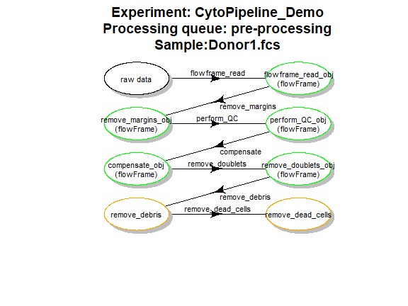

```r
plotCytoPipelineProcessingQueue(pipL,
                                whichQueue = "pre-processing",
                                path = resultsDir,
                                sampleFile = 1)
```

Note that the first five bubbles are now highlighted in green, showing that the first five steps have now produced results. These results have in fact been saved in a data cache, allowing for further visualization of the results.

However, as mentioned earlier, the sixth step, ‘remove_debris’, has resulted in an error, hence there is still not corresponding results, and so the corresponding bubble is still displayed with an orange contour.

Let’s now correct our typo in the json file, and re-run our pipeline, under the same experiment name :

```r
jsonFile <- ("CytoPipeline_Demo_fAI_2.json")

# creation of CytoPipeline object,
# using json file as input
pipL <- CytoPipeline(jsonFile,
                     experimentName = expName,
                     sampleFiles = mySamples)

# execute pipeline
try(execute(pipL, path = resultsDir))
```

```
#> #####################################################
#> ### running SCALE TRANSFORMATION processing steps ###
#> #####################################################
#> Proceeding with step 1 [flowframe_read]: found in cache!
#> Proceeding with step 2 [remove_margins]: found in cache!
#> Proceeding with step 3 [compensate]: found in cache!
#> Proceeding with step 4 [flowframe_aggregate]: found in cache!
#> Proceeding with step 5 [scale_transform_estimate]: found in cache!
#> #####################################################
#> ### NOW PRE-PROCESSING FILE C:/Software/R/rlib/local_devel/CytoPipeline/extdata/Donor1.fcs...
#> #####################################################
#> Proceeding with step 1 [flowframe_read]: found in cache!
#> Proceeding with step 2 [remove_margins]: found in cache!
#> Proceeding with step 3 [perform_QC]: found in cache!
#> Proceeding with step 4 [compensate]: found in cache!
#> Proceeding with step 5 [remove_doublets]: found in cache!
#> Proceeding with step 6 [remove_debris] ...
#> The prior specification has no effect when usePrior=no
#> Using the serial version of flowClust
#> Proceeding with step 7 [remove_dead_cells] ...
#> Removing Dead Cells events (using flowDensity::deGate()) from file : Donor1.fcs
#> Warning: replacing previous import 'flowCore::plot' by 'graphics::plot' when
#> loading 'flowDensity'
#> #####################################################
#> ### NOW PRE-PROCESSING FILE C:/Software/R/rlib/local_devel/CytoPipeline/extdata/Donor2.fcs...
#> #####################################################
#> Proceeding with step 1 [flowframe_read] ...
#> Proceeding with step 2 [remove_margins] ...
#> Removing margins from file : Donor2.fcs
#> Proceeding with step 3 [perform_QC] ...
#> Applying flowAI method...
#> Quality control for the file: Donor2
#> 3.98% of anomalous cells detected in the flow rate check.
#> 0% of anomalous cells detected in signal acquisition check.
#> 0.13% of anomalous cells detected in the dynamic range check.
#> Proceeding with step 4 [compensate] ...
#> Compensating file : Donor2.fcs
#> Proceeding with step 5 [remove_doublets] ...
#> Proceeding with step 6 [remove_debris] ...
#> The prior specification has no effect when usePrior=no
#> Using the serial version of flowClust
#> Proceeding with step 7 [remove_dead_cells] ...
#> Removing Dead Cells events (using flowDensity::deGate()) from file : Donor2.fcs
#> [1] "Only one peak is found, set standard deviation, percentile, or upper arguments accordingly"
#> [1] "Cutoff is based on inflection point."
```

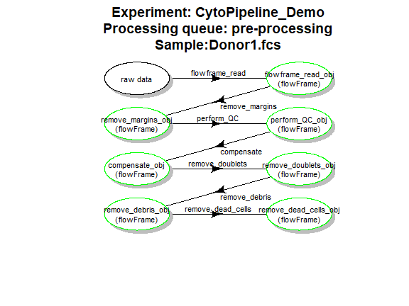

```r
plotCytoPipelineProcessingQueue(pipL,
                                whichQueue = "pre-processing",
                                path = resultsDir,
                                sampleFile = 1)
```

The pipeline now executes correctly! Note that all steps that were previously correctly executed are not re-run, the results are instead read from the data cache.

Let us now visualize our results, using one of the two shiny applications implemented in the *CytoPipelineGUI* package.

```r
# launch shiny app
#CytoPipelineGUI::CytoPipelineCheckApp(dir = resultsDir)
```

When visualizing interactively the results of our pipeline, more specifically when looking at the `remove_debris` step in the FSC-A/SSC-A 2D representation, we can notice that, for the second sample, this step eliminated much more than the undesirable debris events. This has to be improved!

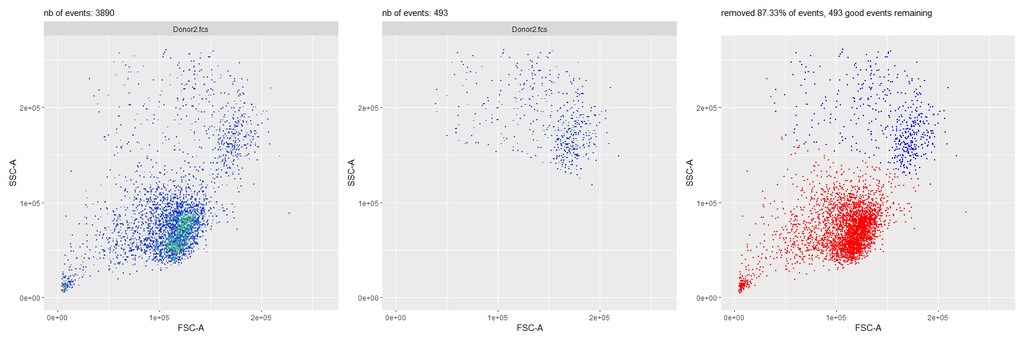

### Running the same pipeline with different function parameters

In order to cope with the issue of the `remove_debris`step, we create a new pipeline with the same steps, only we use `nClust = 3` instead of `nClust = 2` as the number of clusters to be found during this step. We run this amended version of the pipeline under a new experiment name, in order to allow for visual comparison of results between the two versions.

```r
# 3.

# create pipeline with nClust = 3

expName <- "CytoPipeline_Demo_3C"

jsonFile <- ("CytoPipeline_Demo_fAI_3C.json")

pipL2 <- CytoPipeline(jsonFile,
                      experimentName = expName,
                      sampleFiles = mySamples)


# execute pipeline
execute(pipL2, path = resultsDir)
```

```
#> #####################################################
#> ### running SCALE TRANSFORMATION processing steps ###
#> #####################################################
#> Proceeding with step 1 [flowframe_read] ...
#> Proceeding with step 2 [remove_margins] ...
#> Removing margins from file : Donor1.fcs
#> Removing margins from file : Donor2.fcs
#> Proceeding with step 3 [compensate] ...
#> Compensating file : Donor1.fcs
#> Compensating file : Donor2.fcs
#> Proceeding with step 4 [flowframe_aggregate] ...
#> Proceeding with step 5 [scale_transform_estimate] ...
#> estimating logicle transformations for fluorochrome channels...
#> Estimating linear transformation for scatter channels : reference marker = CD4...
#> applying specific linear transformation for FSC-A channel...
#> initial quantiles : q5 = 15825.9604 ; q95 = 182291.0469
#> target quantiles : q5 = 0.4556 ; q95 = 2.8719
#> a = 1.45e-05 ; b = 2.26e-01
#> applying FSC-A linear transformation for FSC-H channel...
#> applying specific linear transformation for SSC-A channel...
#> initial quantiles : q5 = 23846.3145 ; q95 = 222903.9688
#> target quantiles : q5 = 0.4556 ; q95 = 2.8719
#> a = 1.21e-05 ; b = 1.66e-01
#> applying SSC-A linear transformation for SSC-H channel...
#> #####################################################
#> ### NOW PRE-PROCESSING FILE C:/Software/R/rlib/local_devel/CytoPipeline/extdata/Donor1.fcs...
#> #####################################################
#> Proceeding with step 1 [flowframe_read] ...
#> Proceeding with step 2 [remove_margins] ...
#> Removing margins from file : Donor1.fcs
#> Proceeding with step 3 [perform_QC] ...
#> Applying flowAI method...
#> Quality control for the file: Donor1
#> 3.56% of anomalous cells detected in the flow rate check.
#> 0% of anomalous cells detected in signal acquisition check.
#> 0.02% of anomalous cells detected in the dynamic range check.
#> Proceeding with step 4 [compensate] ...
#> Compensating file : Donor1.fcs
#> Proceeding with step 5 [remove_doublets] ...
#> Proceeding with step 6 [remove_debris] ...
```

[output cut: 9 more lines]

```
#> Removing margins from file : Donor2.fcs
#> Proceeding with step 3 [perform_QC] ...
#> Applying flowAI method...
#> Quality control for the file: Donor2
#> 3.98% of anomalous cells detected in the flow rate check.
#> 0% of anomalous cells detected in signal acquisition check.
#> 0.13% of anomalous cells detected in the dynamic range check.
#> Proceeding with step 4 [compensate] ...
#> Compensating file : Donor2.fcs
#> Proceeding with step 5 [remove_doublets] ...
#> Proceeding with step 6 [remove_debris] ...
#> The prior specification has no effect when usePrior=no
#> Using the serial version of flowClust
#> Proceeding with step 7 [remove_dead_cells] ...
#> Removing Dead Cells events (using flowDensity::deGate()) from file : Donor2.fcs
```

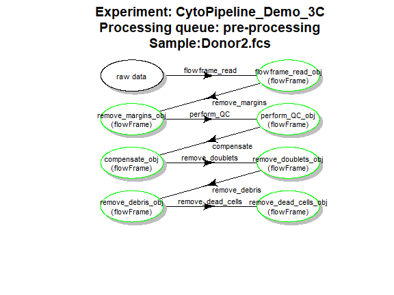

```r
plotCytoPipelineProcessingQueue(pipL2,
                                whichQueue = "pre-processing",
                                path = resultsDir,
                                sampleFile = 2)
```

Now that this pipeline has run until completion, we can now visualize interactively what the `remove_debris` gives as results, with this new `nClust = 3` parameter. We can notice that the debris removal, for sample 2, has worked much better with this new parameter setting.

```r
# launch shiny app
#CytoPipelineGUI::CytoPipelineCheckApp(dir = resultsDir)
```

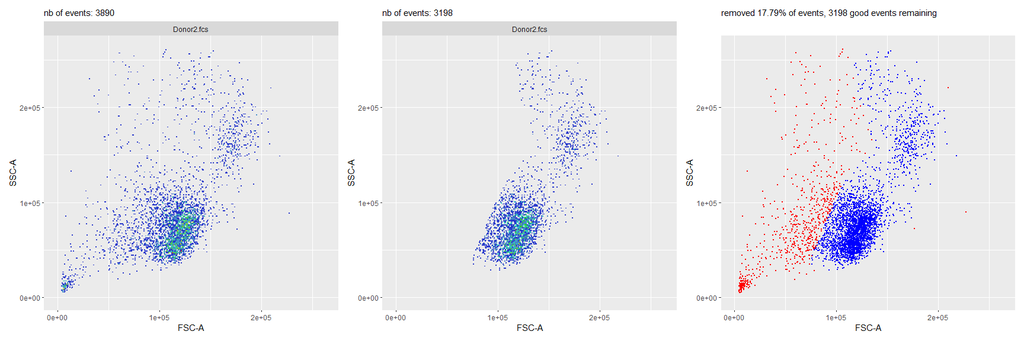

### Comparing pipelines

In this section, we will run the alternative pipeline using *PeacoQC* as QC in time method, and then compare with what we get with *flowAI*. As mentioned in the introduction, the *PeacoQC* pipeline implies a slightly order of the steps as well. The pipeline is described in the following json file:

```r
jsonFile <- ("CytoPipeline_Demo_PQC.json")
cat(readLines(jsonFile), sep = '\n')
{
  "scaleTransformProcessingSteps": [
    {
      "name": ["flowframe_read"],
      "FUN": ["readSampleFiles"],
      "ARGS": {
        "whichSamples": ["all"],
        "truncate_max_range": [false],
        "min.limit": null
      }
    },
    {
      "name": ["remove_margins"],
      "FUN": ["removeMarginsPeacoQC"],
      "ARGS": {
        "channelSpecifications": {
          "AllFluoChannels": [-300, 262144]
        }
      }
    },
    {
      "name": ["compensate"],
      "FUN": ["compensateFromMatrix"],
      "ARGS": {
        "matrixSource": ["fcs"]
      }
    },
    {
      "name": ["flowframe_aggregate"],
      "FUN": ["aggregateAndSample"],
      "ARGS": {
        "nTotalEvents": [10000],
        "seed": [0]
      }
    },
    {
      "name": ["scale_transform_estimate"],
      "FUN": ["estimateScaleTransforms"],
      "ARGS": {
        "fluoMethod": ["estimateLogicle"],
        "scatterMethod": ["linearQuantile"],
        "scatterRefMarker": ["CD4"]
      }
    }
  ],
  "flowFramesPreProcessingSteps": [
    {
      "name": ["flowframe_read"],
      "FUN": ["readSampleFiles"],
      "ARGS": {
        "truncate_max_range": [false],
        "min.limit": null
      }
    },
    {
      "name": ["remove_margins"],
      "FUN": ["removeMarginsPeacoQC"],
      "ARGS": {
        "channelSpecifications": {
          "AllFluoChannels": [-300, 262144]
        }
      }
    },
    {
      "name": ["compensate"],
      "FUN": ["compensateFromMatrix"],
      "ARGS": {
        "matrixSource": ["fcs"]
      }
    },
    {
      "name": ["perform_QC"],
      "FUN": ["qualityControlPeacoQC"],
      "ARGS": {
        "preTransform": [true],
        "min_cells": [150],
        "max_bins": [500],
        "step": [500],
        "MAD": [6],
        "IT_limit": [0.55],
        "force_IT": [150],
        "peak_removal": [0.3333],
        "min_nr_bins_peakdetection": [10]
      }
    },
    {
      "name": ["remove_doublets"],
      "FUN": ["removeDoubletsCytoPipeline"],
      "ARGS": {
        "areaChannels": ["FSC-A"],
        "heightChannels": ["FSC-H"],
        "nmads": [3]
      }
    },
    {
      "name": ["remove_debris"],
      "FUN": ["removeDebrisFlowClustTmix"],
      "ARGS": {
        "FSCChannel": ["FSC-A"],
        "SSCChannel": ["SSC-A"],
        "nClust": [3],
        "level": [0.97],
        "B": [100]}
    },
    {
      "name": ["remove_dead_cells"],
      "FUN": ["removeDeadCellsDeGate"],
      "ARGS": {
        "preTransform": [true],
        "LDMarker": ["L/D Aqua - Viability"]
      }
    }
  ]
}
```

Let us now create a new CytoPipeline object, and execute it.

```r
# 4.
# creation of a new CytoPipeline object,
# using json file as input (flowAI)
pipL_PQC <- CytoPipeline(jsonFile,
                         experimentName = "CytoPipeline_Demo_PQC",
                         sampleFiles = mySamples)

# display CytoPipeline object
pipL_PQC
```

```
#> Pipeline object for flow cytometry experiment: CytoPipeline_Demo_PQC
#> Sample files: 2 sample file(s)
#> No pheno data
#> Scale transformations evaluation queue : 5 processing step(s)
#> 1 :Object of class "CytoProcessingStep"
#>  Name: flowframe_read
#>  Function: readSampleFiles
#>  Arguments:
#>   o whichSamples = all
#>   o truncate_max_range = FALSE
#>   o min.limit =
#> 2 :Object of class "CytoProcessingStep"
#>  Name: remove_margins
#>  Function: removeMarginsPeacoQC
#>  Arguments:
#>   o channelSpecifications = c(-300, 262144)
#> 3 :Object of class "CytoProcessingStep"
#>  Name: compensate
#>  Function: compensateFromMatrix
#>  Arguments:
#>   o matrixSource = fcs
#> 4 :Object of class "CytoProcessingStep"
#>  Name: flowframe_aggregate
#>  Function: aggregateAndSample
#>  Arguments:
#>   o nTotalEvents = 10000
#>   o seed = 0
#> 5 :Object of class "CytoProcessingStep"
#>  Name: scale_transform_estimate
#>  Function: estimateScaleTransforms
#>  Arguments:
#>   o fluoMethod = estimateLogicle
#>   o scatterMethod = linearQuantile
#>   o scatterRefMarker = CD4
#> Flow frames pre-processing evaluation queue : 7 processing step(s)
#> 1 :Object of class "CytoProcessingStep"
#>  Name: flowframe_read
#>  Function: readSampleFiles
#>  Arguments:
#>   o truncate_max_range = FALSE
```

[output cut: 31 more lines]

```
#> 6 :Object of class "CytoProcessingStep"
#>  Name: remove_debris
#>  Function: removeDebrisFlowClustTmix
#>  Arguments:
#>   o FSCChannel = FSC-A
#>   o SSCChannel = SSC-A
#>   o nClust = 3
#>   o level = 0.97
#>   o B = 100
#> 7 :Object of class "CytoProcessingStep"
#>  Name: remove_dead_cells
#>  Function: removeDeadCellsDeGate
#>  Arguments:
#>   o preTransform = TRUE
#>   o LDMarker = L/D Aqua - Viability
```

```r
# execute pipeline
execute(pipL_PQC, path = resultsDir)
```

```
#> #####################################################
#> ### running SCALE TRANSFORMATION processing steps ###
#> #####################################################
#> Proceeding with step 1 [flowframe_read] ...
#> Proceeding with step 2 [remove_margins] ...
#> Removing margins from file : Donor1.fcs
#> Removing margins from file : Donor2.fcs
#> Proceeding with step 3 [compensate] ...
#> Compensating file : Donor1.fcs
#> Compensating file : Donor2.fcs
#> Proceeding with step 4 [flowframe_aggregate] ...
#> Proceeding with step 5 [scale_transform_estimate] ...
#> estimating logicle transformations for fluorochrome channels...
#> Estimating linear transformation for scatter channels : reference marker = CD4...
#> applying specific linear transformation for FSC-A channel...
#> initial quantiles : q5 = 15825.9604 ; q95 = 182291.0469
#> target quantiles : q5 = 0.4556 ; q95 = 2.8719
#> a = 1.45e-05 ; b = 2.26e-01
#> applying FSC-A linear transformation for FSC-H channel...
#> applying specific linear transformation for SSC-A channel...
#> initial quantiles : q5 = 23846.3145 ; q95 = 222903.9688
#> target quantiles : q5 = 0.4556 ; q95 = 2.8719
#> a = 1.21e-05 ; b = 1.66e-01
#> applying SSC-A linear transformation for SSC-H channel...
#> #####################################################
#> ### NOW PRE-PROCESSING FILE C:/Software/R/rlib/local_devel/CytoPipeline/extdata/Donor1.fcs...
#> #####################################################
#> Proceeding with step 1 [flowframe_read] ...
#> Proceeding with step 2 [remove_margins] ...
#> Removing margins from file : Donor1.fcs
#> Proceeding with step 3 [compensate] ...
#> Compensating file : Donor1.fcs
#> Proceeding with step 4 [perform_QC] ...
#> Applying PeacoQC method...
#> Starting quality control analysis for Donor1.fcs
#> Warning in FindIncreasingDecreasingChannels(breaks, ff, channels, plot, : There
#> seems to be an increasing or decreasing trend in a channel for Donor1.fcs .
#> Please inspect this in the overview figure.
#> Calculating peaks
#> Warning in PeacoQC::PeacoQC(ff = ffIn, channels = channel4QualityControl, :
```

[output cut: 19 more lines]

```
#> Starting quality control analysis for Donor2.fcs
#> Warning in FindIncreasingDecreasingChannels(breaks, ff, channels, plot, : There
#> seems to be an increasing or decreasing trend in a channel for Donor2.fcs .
#> Please inspect this in the overview figure.
#> Calculating peaks
#> Warning in PeacoQC::PeacoQC(ff = ffIn, channels = channel4QualityControl, :
#> There are not enough bins for a robust isolation tree analysis.
#> MAD analysis removed 11.42% of the measurements
#> The algorithm removed 11.42% of the measurements
#> Proceeding with step 5 [remove_doublets] ...
#> Proceeding with step 6 [remove_debris] ...
#> The prior specification has no effect when usePrior=no
#> Using the serial version of flowClust
#> Proceeding with step 7 [remove_dead_cells] ...
#> Removing Dead Cells events (using flowDensity::deGate()) from file : Donor2.fcs
```

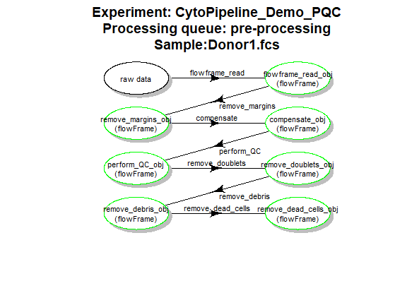

```r
plotCytoPipelineProcessingQueue(pipL_PQC,
                                whichQueue = "pre-processing",
                                path = resultsDir,
                                sampleFile = 1)
```

The pipeline having run until completion, time to visualize the results!

```r
#CytoPipelineGUI::CytoPipelineCheckApp(dir = resultsDir)
```

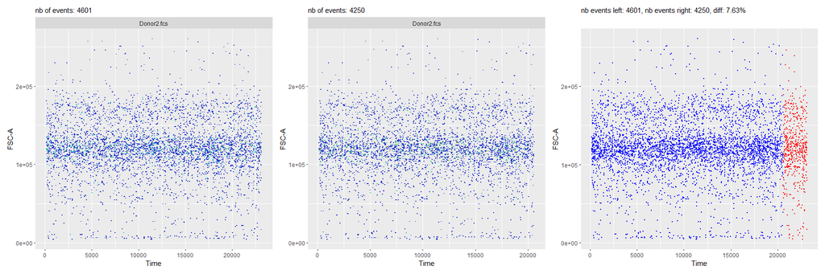

## Visualization of scale transformations

Besides the flowFrame comparison tool, *CytoPipelineGUI* provides another shiny app, which allows to interactively visualize and manage the scale transformations that are generated as part of our prep-processing pipelines.

If the shape of the scale transformations that were automatically set by the chosen algorithm appears to be non satisfactory, it is possible, using this shiny application, to manually adjust the parameters of the transformation, and save the results in a RDS object. This object can then be re-used in another pipeline instance.

```r
# 5. show scale transformations
#CytoPipelineGUI::ScaleTransformApp(dir = resultsDir)
```

## Some technical options to fine-tune pipeline execution

To end up with this workshop, let us experiment with some technical options that are available to fine-tune the pipeline execution.

### Cleaning the results cache before running

We have mentioned earlier that the results produced at each step are stored in a cache, allowing for further visual assessment. This cache is built thanks to the Bioconductor package `BiocFileCache`.

As a matter of fact, this caching mechanism also allows to re-use previously obtained results in case of a re-run, because by default, the cache will not be erased before running again the pipeline.

However, it could be useful in some cases to erase the cache prior to running. This can for example happen when re-running the pipeline with the same experiment id, but with an amended pipeline definition.

For this, the `rmCache` parameter of the `execute()` function can be set to `TRUE`.

```r
# 6a. execute pipeline with rmCache = TRUE

execute(pipL_PQC, path = resultsDir, rmCache = TRUE)
```

```
#> Warning in execute(pipL_PQC, path = resultsDir, rmCache = TRUE): Found a
#> previous cache with experiment name CytoPipeline_Demo_PQC => removed it
#> #####################################################
#> ### running SCALE TRANSFORMATION processing steps ###
#> #####################################################
#> Proceeding with step 1 [flowframe_read] ...
#> Proceeding with step 2 [remove_margins] ...
#> Removing margins from file : Donor1.fcs
#> Removing margins from file : Donor2.fcs
#> Proceeding with step 3 [compensate] ...
#> Compensating file : Donor1.fcs
#> Compensating file : Donor2.fcs
#> Proceeding with step 4 [flowframe_aggregate] ...
#> Proceeding with step 5 [scale_transform_estimate] ...
#> estimating logicle transformations for fluorochrome channels...
#> Estimating linear transformation for scatter channels : reference marker = CD4...
#> applying specific linear transformation for FSC-A channel...
#> initial quantiles : q5 = 15825.9604 ; q95 = 182291.0469
#> target quantiles : q5 = 0.4556 ; q95 = 2.8719
#> a = 1.45e-05 ; b = 2.26e-01
#> applying FSC-A linear transformation for FSC-H channel...
#> applying specific linear transformation for SSC-A channel...
#> initial quantiles : q5 = 23846.3145 ; q95 = 222903.9688
#> target quantiles : q5 = 0.4556 ; q95 = 2.8719
#> a = 1.21e-05 ; b = 1.66e-01
#> applying SSC-A linear transformation for SSC-H channel...
#> #####################################################
#> ### NOW PRE-PROCESSING FILE C:/Software/R/rlib/local_devel/CytoPipeline/extdata/Donor1.fcs...
#> #####################################################
#> Proceeding with step 1 [flowframe_read] ...
#> Proceeding with step 2 [remove_margins] ...
#> Removing margins from file : Donor1.fcs
#> Proceeding with step 3 [compensate] ...
#> Compensating file : Donor1.fcs
#> Proceeding with step 4 [perform_QC] ...
#> Applying PeacoQC method...
#> Starting quality control analysis for Donor1.fcs
#> Warning in FindIncreasingDecreasingChannels(breaks, ff, channels, plot, : There
#> seems to be an increasing or decreasing trend in a channel for Donor1.fcs .
#> Please inspect this in the overview figure.
```

[output cut: 21 more lines]

```
#> Starting quality control analysis for Donor2.fcs
#> Warning in FindIncreasingDecreasingChannels(breaks, ff, channels, plot, : There
#> seems to be an increasing or decreasing trend in a channel for Donor2.fcs .
#> Please inspect this in the overview figure.
#> Calculating peaks
#> Warning in PeacoQC::PeacoQC(ff = ffIn, channels = channel4QualityControl, :
#> There are not enough bins for a robust isolation tree analysis.
#> MAD analysis removed 11.42% of the measurements
#> The algorithm removed 11.42% of the measurements
#> Proceeding with step 5 [remove_doublets] ...
#> Proceeding with step 6 [remove_debris] ...
#> The prior specification has no effect when usePrior=no
#> Using the serial version of flowClust
#> Proceeding with step 7 [remove_dead_cells] ...
#> Removing Dead Cells events (using flowDensity::deGate()) from file : Donor2.fcs
```